### Map of eelgrass beds

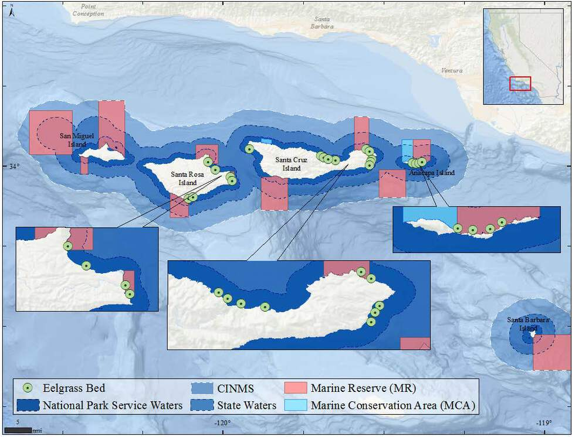

**Figure App.E.10.22.**. A map showing eelgrass bed locations around the Northern Channel Islands.

**Click for Details**

CINMS eelgrass bed locations in the map above are a compilation from UCSB, NMFS, and CINMS data. Surveys for eelgrass occurred at different times and the bed persistence is unknown at many locations. UCSB data comes from transects performed by UCSB researchers while the NMFS data comes from sidescan sonar surveys along the coastline. Data source: NMFS, UCSB, and CINMS; Map: [M. Cajandig/NOAA](https://channelislands.noaa.gov/contact/cajandig.html)

### Eelgrass extent Anacapa Island

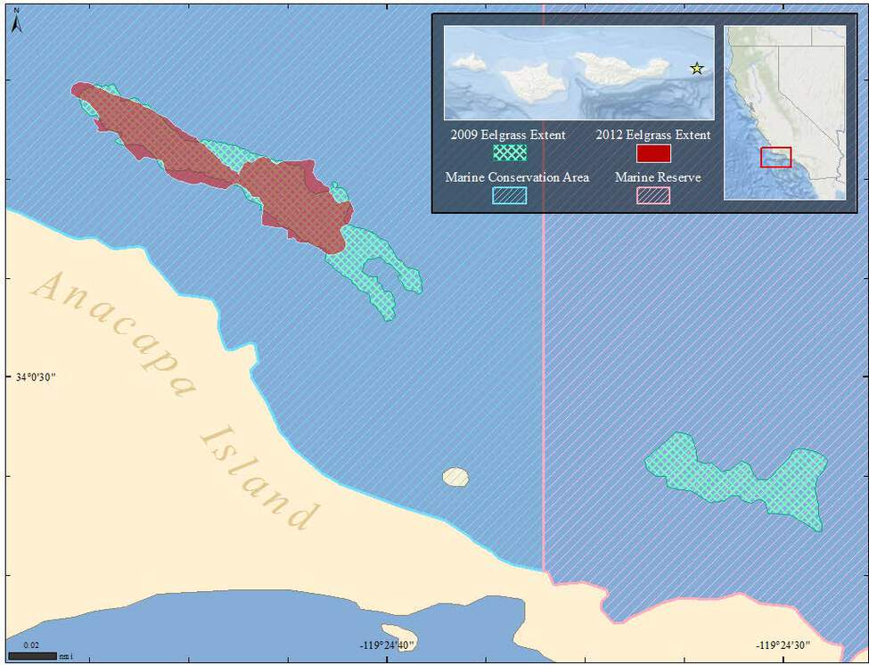

**Figure App.E.10.24.**. A map showing eelgrass beds mapped by diver surveys on Anacapa Island in 2009 (light blue) and 2012 (dark red).

**Click for Details**

Eelgrass bed extent from diver surveys at Anacapa Island in 2009 (light blue) and 2012 (dark red). Overall, bed extent appears to be declining at Anacapa between 2009 and 2012, with the eastern bed being extirpated. Trap fishing, anchoring, and seafloor disturbance are thought to contribute to declines in bed extent and shoot density, with eelgrass beds inside the marine reserve having higher shoot density than those in areas with less protection. Data source: J. Altstatt/ UCSB and CINMS; [Map: M. Cajandig/NOAA](https://channelislands.noaa.gov/contact/cajandig.html)

### Eelgrass extent Santa Cruz Island

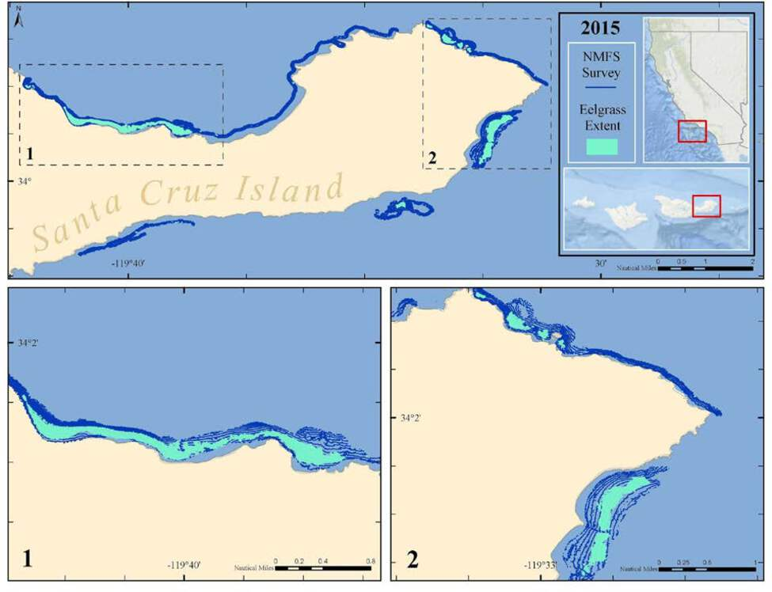

**Figure App.E.10.25.**. A map showing eelgrass beds on Santa Cruz Island from a 2015 survey using sidescan sonar.

**Click for Details**

National Marine Fisheries Service surveys in 2015 for eelgrass using interferometric sidescan sonar to map bed extent are shown. Dark blue represents bathylines generated from the sidescan data and area surveyed. Turquoise areas represents eelgrass bed extent generated from sidescan data. Eelgrass beds in these areas are thought to have persisted for long periods of time and appear to be relatively stable; however, surveys on the eelgrass health and shoot density have not been conducted. Data source: NMFS; Map: [M. Cajandig/NOAA](https://channelislands.noaa.gov/contact/cajandig.html)

### Eelgrass cover Frenchy’s Cove

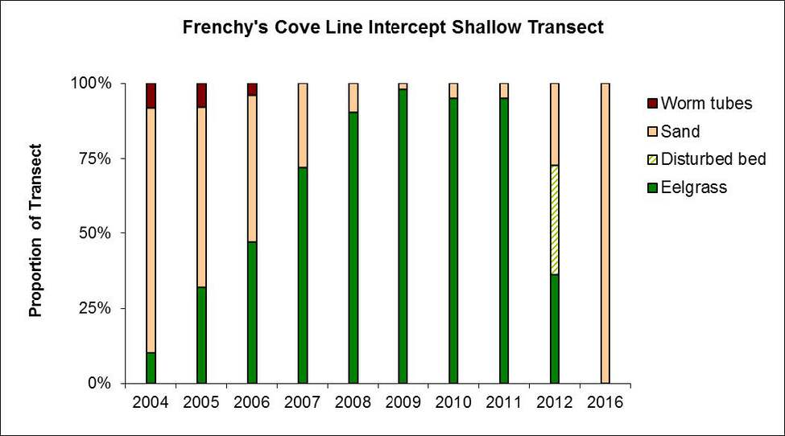

**Figure S.Hab.10.3.**. A figure showing the amount of eelgrass in Frenchy’s Cove, Anacapa Island, from 2004 - 2016.

**Click for Details**

Eelgrass cover at Frenchy’s Cove from 2004 to 2016 after 2003 transplant. Data are collected from diver surveys along a 30 meter fixed transect with points scored every 10 centimeters. The transect lies within the transplant area at Frenchy’s Cove are at approximately 24 feet in depth. Declines in eelgrass cover are thought to be potentially due to seafloor disturbance from anchoring and trap fishing. Figure: [J. Altstatt/UCSB and NOAA](http://msi.ucsb.edu/people/project-staff/jessie%C2%A0altstatt)